# Oligopoly Practice

Answer Key

ECON 316 — Game Theory — Fall 2021

Suppose Firm 1 and Firm 2 have a constant $MC=AC=8$. The market (inverse) demand curve is given by:

$$\begin{align*}
P&=200-2Q\\
Q&=q_1+q_2\\
\end{align*}$$

## Question 1

#### Find the Cournot-Nash equilibrium output and profit for each firm.

Break demand apart into both firms’ output.
$$\begin{align*}
P&=200-2Q\\
P&=200-2(q_{1}+q_{2})\\
P&=200-2q_{1}-2q_2\\
\end{align*}$$

Solving for Firm 1, recalling that MR is twice the slope of the inverse demand curve:

$$MR_{1}=200-4q_{1}-2q_2$$

Firm 1 maximizes profit at $q^*$ where $MR=MC$:
$$\begin{align*}
MR_{1}&=MC && \text{Profit-max condition} \\
200-4q_{1}-2q_2&=8 && \text{Plugging in}\\
192-4q_1-2q_2&=0 && \text{Subtracting 8 from both sides}\\
192-2q_2&=4q_1 && \text{Adding }4q_{1} \text{ to both sides}\\
48-0.5q_1&=q_1^* && \text{Dividing both sides by 4}\\
\end{align*}$$

- Since Firm 2 is identical, its $q^*$ is:

$$q_2^*=48-0.5q_{1}$$

Find Nash equilibrium algebraically by plugging in one firm’s reaction curve into the other’s

$$\begin{align*}
q_{1}&=48-0.5q_2 && \text{Firm 1's reaction function}\\
q_{1}&=48-0.5(48-0.5q_{1}) && \text{Plugging in Firm 2's reaction function}\\
q_{1}&=48-24+0.25q_{1} && \text{Distributing the }-0.5\\
q_{1}&=24+0.25q_{1} && \text{Subtracting}\\
0.75q_{1}&=24 && \text{Subtracting }0.25q_{1} \text{ to both sides}\\
q_{1}&=32 && \text{Dividing by 0.75}\\
\end{align*}$$

Symmetrically, $q_{2}=32$

Both countries produce 32:

$$\begin{align*}
P&=200-2(32)-2(32)\\
P&=\$72\\
\end{align*}$$

We can find the profit for each firm:

$$\begin{align*}
\pi_{1}&=q_{1}(P-c)\\
\pi_{1}&=32(72-8)\\
\pi_{1}&=\$2,048\\
\end{align*}$$

## Question 2

#### Find the output and profit for each firm if the two were to collude.

Suppose now both firms **collude** and act like a single monopolist, who sets:

$$\begin{align*}
MR&=MC && \text{Profit-max condition}\\
200-4Q&=8 && \text{Plugging in}\\
192-4Q&=0 && \text{Subtracting 8 from both sides}\\
192&=4Q && \text{Adding }4Q \text{ to both sides}\\
48&=Q && \text{Dividing both sides by 4}\\
\end{align*}$$

So each firm will produce 24.

The monopoly price will then be

$$\begin{align*}
P&=200-2Q\\
P&=200-2(48)\\
P&=\$104\\
\end{align*}$$

Total profit will then be:

$$\begin{align*}
\Pi&=Q(P-c)\\
\Pi&=48(104-8)\\
\Pi&=\$4,608\\
\end{align*}$$

with $2,304 going to each firm

## Question 3

#### Find the price and output if the two were to compete on price instead of quantity.

In Bertrand competition, each firm sets:

$$\begin{align*}
P&=MC\\
200-2Q&=8\\
192-2Q&=0\\
192&=2Q\\
96&=Q\\
\end{align*}$$

Each firm produces 48, earning no profits.

## Question 4

#### Suppose Firm 1 produces before Firm 2, who can see how much Firm 1 produced. Find the price, output, and profit for each firm.

Substitute follower’s reaction function into market (inverse) demand function

- Find $MR$ for Firm 1 from market demand

$$MR_{1}=104-2q_{1}$$

$$\begin{align*}
MR&=MC && \text{Profit-max condition}\\
104-2q_{1}&=8 && \text{Plugging in}\\
104&=8+2q_{sa} && \text{Adding }2q_{1} \text{ to both sides}\\
96&=2q_{sa} && \text{Subtracting 20 from both sides}\\
48&=q_{sa}^* && \text{Dividing both sides by 2} \\
\end{align*}$$

- Firm 2 will respond

$$\begin{align*}
q_2^*&=48-0.5q_{1}\\
q_2^*&=48-0.5(48)\\
q_2^*&=48-24\\
q_2^*&=24\\
\end{align*}$$

- With $q^*_{1}=48$ and $q^*_2=24$, this sets a market price of

$$\begin{align*}
P&=200-2Q\\
P&=200-2(72)\\
P&=56\\
\end{align*}$$

- Profit for Firm 1 is

$$\begin{align*}
\pi_{1}&=q_{1}(P-c)\\
\pi_{1}&=48(56-8)\\
\pi_{1}&=\$2,304\\
\end{align*}$$

- Profit for Firm 2 is

$$\begin{align*}
\pi_{2}&=q_{2}(P-c)\\
\pi_{2}&=24(56-8)\\
\pi_{2}&=\$1,152\\
\end{align*}$$

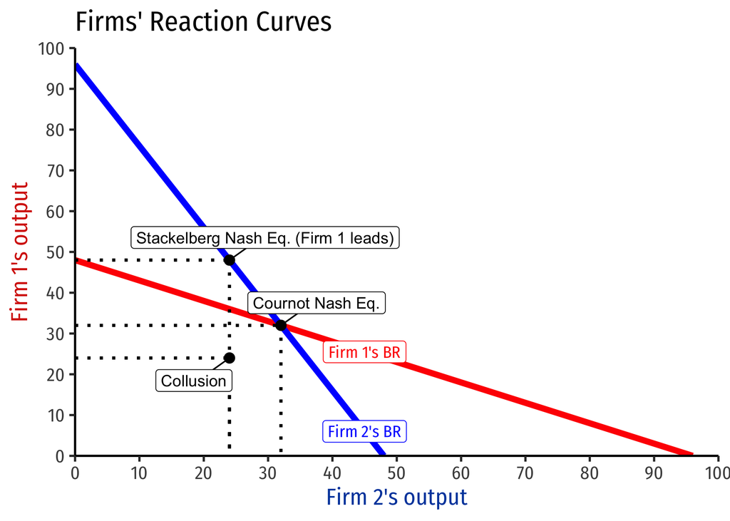

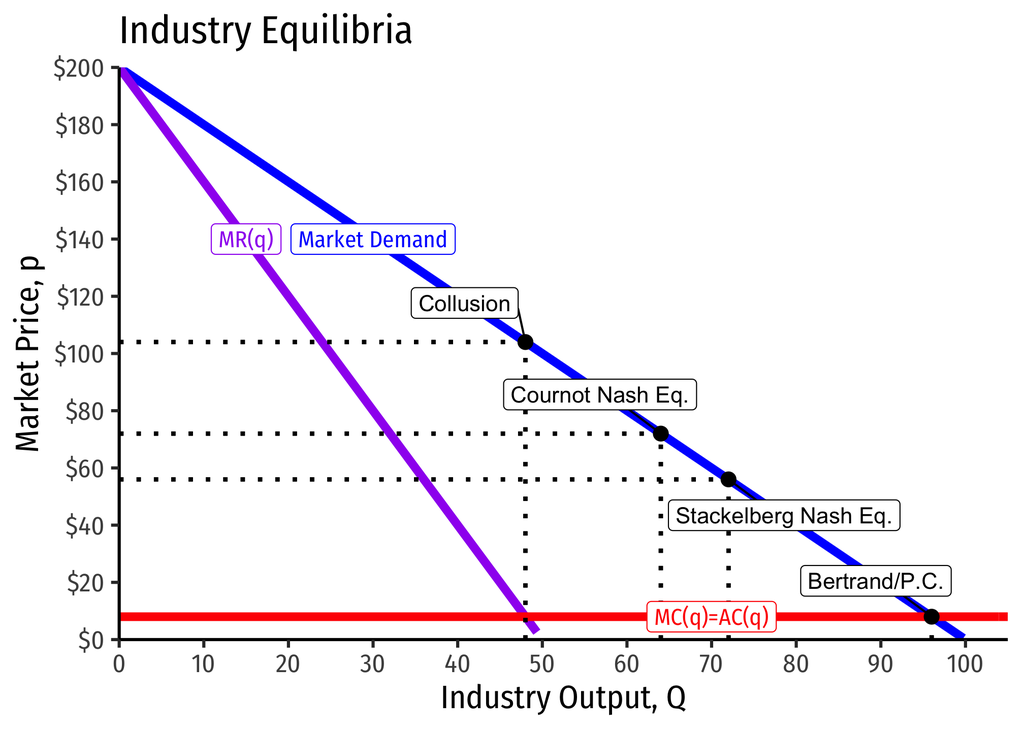